# Reproducible Research: Peer Assessment 2

Jarren Santos

2/20/2017

# Fatalities, Injuries, and a Bit of Rain: A Simple Analysis

## Synopsis

Storms and other severe weather events can cause problems in a variety sectors. In public health, communities are often left in an uninhabitable state where families and individuals may struggle to obtain access to resources they had once before. In economics, storms wipe out much of the supply for materials and resources, which negatively impacts the market of an entire area or region. In either case, severe events like storms may cause fatalities in the form of injuries, deaths, or property damage. Using the NOAA Storm Database, we wish to answer two different questions:

1. Across the United States, which types of events are most harmful with respect to population health (see `EVTYPE` variable)?
2. Across the United States, which types of events have the greatest economic consequences?

By analyzing the information available on the NOAA Storm Database, we can get an idea of how storms and fatal events are related.

## Setup

Set your working directory to wherever your work is going to be placed in and where you are sourcing your data from.

```r
setwd("~/Documents/Grinnell College/04_Spring 2017/MAT-397 (Adv Data Sci)/Coursera/05_Reproducible Research/Week 04")
```

You will need to have the following packages installed:

- `readr` package: Allows you to read in data more efficiently

```r
require(readr)
require(plyr)
require(dplyr)
```

```r
require(ggplot2)
require(gridExtra)
```

## Data Processing

We’ll load in the Storms database. If you do not have the Storms database on your local computer, you can click [this link](https://d396qusza40orc.cloudfront.net/repdata%2Fdata%2FStormData.csv.bz2) to download it. NA strings are recorded as blank values, so we specify that with the `na` argument.

When reading data in, I like to use the `read_csv()` function from the `readr` package. However, feel free to use the base package’s `read.csv()` function. `readcsv()` allows for more efficient processing when loading data into R.

```r
storms <- read_csv("repdata%2Fdata%2FStormData.csv.bz2", na = c(""))
```

Let’s preview the data so we can capture a quick glimpse of what it contains.

```r
str(storms)
```

```
## Classes 'tbl_df', 'tbl' and 'data.frame':    902297 obs. of  37 variables:
##  $ STATE__   : num  1 1 1 1 1 1 1 1 1 1 ...
##  $ BGN_DATE  : chr  "4/18/1950 0:00:00" "4/18/1950 0:00:00" "2/20/1951 0:00:00" "6/8/1951 0:00:00" ...
##  $ BGN_TIME  : chr  "0130" "0145" "1600" "0900" ...
##  $ TIME_ZONE : chr  "CST" "CST" "CST" "CST" ...
##  $ COUNTY    : num  97 3 57 89 43 77 9 123 125 57 ...
##  $ COUNTYNAME: chr  "MOBILE" "BALDWIN" "FAYETTE" "MADISON" ...
##  $ STATE     : chr  "AL" "AL" "AL" "AL" ...
##  $ EVTYPE    : chr  "TORNADO" "TORNADO" "TORNADO" "TORNADO" ...
##  $ BGN_RANGE : num  0 0 0 0 0 0 0 0 0 0 ...
##  $ BGN_AZI   : chr  NA NA NA NA ...
##  $ BGN_LOCATI: chr  NA NA NA NA ...
##  $ END_DATE  : chr  NA NA NA NA ...
##  $ END_TIME  : chr  NA NA NA NA ...
##  $ COUNTY_END: num  0 0 0 0 0 0 0 0 0 0 ...
##  $ COUNTYENDN: chr  NA NA NA NA ...
##  $ END_RANGE : num  0 0 0 0 0 0 0 0 0 0 ...
##  $ END_AZI   : chr  NA NA NA NA ...
##  $ END_LOCATI: chr  NA NA NA NA ...
##  $ LENGTH    : num  14 2 0.1 0 0 1.5 1.5 0 3.3 2.3 ...
##  $ WIDTH     : num  100 150 123 100 150 177 33 33 100 100 ...
##  $ F         : int  3 2 2 2 2 2 2 1 3 3 ...
##  $ MAG       : num  0 0 0 0 0 0 0 0 0 0 ...
##  $ FATALITIES: num  0 0 0 0 0 0 0 0 1 0 ...
##  $ INJURIES  : num  15 0 2 2 2 6 1 0 14 0 ...
##  $ PROPDMG   : num  25 2.5 25 2.5 2.5 2.5 2.5 2.5 25 25 ...
##  $ PROPDMGEXP: chr  "K" "K" "K" "K" ...
##  $ CROPDMG   : num  0 0 0 0 0 0 0 0 0 0 ...
##  $ CROPDMGEXP: chr  NA NA NA NA ...
##  $ WFO       : chr  NA NA NA NA ...
##  $ STATEOFFIC: chr  NA NA NA NA ...
##  $ ZONENAMES : chr  NA NA NA NA ...
##  $ LATITUDE  : num  3040 3042 3340 3458 3412 ...
##  $ LONGITUDE : num  8812 8755 8742 8626 8642 ...
##  $ LATITUDE_E: num  3051 0 0 0 0 ...
##  $ LONGITUDE_: num  8806 0 0 0 0 ...
##  $ REMARKS   : chr  NA NA NA NA ...
##  $ REFNUM    : num  1 2 3 4 5 6 7 8 9 10 ...
##  - attr(*, "spec")=List of 2
##   ..$ cols   :List of 37
```

[output cut: 62 more lines]

[output not shown]

```r
head(storms)
```

```
## Source: local data frame [6 x 37]
##
##   STATE__           BGN_DATE BGN_TIME TIME_ZONE COUNTY COUNTYNAME STATE
##     (dbl)              (chr)    (chr)     (chr)  (dbl)      (chr) (chr)
## 1       1  4/18/1950 0:00:00     0130       CST     97     MOBILE    AL
## 2       1  4/18/1950 0:00:00     0145       CST      3    BALDWIN    AL
## 3       1  2/20/1951 0:00:00     1600       CST     57    FAYETTE    AL
## 4       1   6/8/1951 0:00:00     0900       CST     89    MADISON    AL
## 5       1 11/15/1951 0:00:00     1500       CST     43    CULLMAN    AL
## 6       1 11/15/1951 0:00:00     2000       CST     77 LAUDERDALE    AL
## Variables not shown: EVTYPE (chr), BGN_RANGE (dbl), BGN_AZI (chr),
##   BGN_LOCATI (chr), END_DATE (chr), END_TIME (chr), COUNTY_END (dbl),
##   COUNTYENDN (chr), END_RANGE (dbl), END_AZI (chr), END_LOCATI (chr),
##   LENGTH (dbl), WIDTH (dbl), F (int), MAG (dbl), FATALITIES (dbl),
##   INJURIES (dbl), PROPDMG (dbl), PROPDMGEXP (chr), CROPDMG (dbl),
##   CROPDMGEXP (chr), WFO (chr), STATEOFFIC (chr), ZONENAMES (chr), LATITUDE
##   (dbl), LONGITUDE (dbl), LATITUDE_E (dbl), LONGITUDE_ (dbl), REMARKS
##   (chr), REFNUM (dbl)
```

Now that we have our data loaded in, we can analylze our data with regards to our question.

## Data Wrangling

Let’s get an idea of the data that we are working with. We saw in the `str(storms)` command the structure of each of those variables along with their names. The variables we probably will be most concerned with are:

- STATE
- EVTYPE
- FATALATIES
- INJURIES
- PROPDMG
- PROPDMGEXP
- CROPDMG
- CROPDMGEXP

Let’s change our dataset up a bit by selecting only the variables of our interest.

```r
storms <- select(storms, STATE, EVTYPE, FATALITIES, INJURIES, PROPDMG, PROPDMGEXP, CROPDMG, CROPDMGEXP)
```

We can obtain a five-number summary for each of the quantitative variables by using the `summary()` command.

```r
summary(storms$FATALITIES)
```

```
##     Min.  1st Qu.   Median     Mean  3rd Qu.     Max.
##   0.0000   0.0000   0.0000   0.0168   0.0000 583.0000
```

```r
summary(storms$INJURIES)
```

```
##      Min.   1st Qu.    Median      Mean   3rd Qu.      Max.
##    0.0000    0.0000    0.0000    0.1557    0.0000 1700.0000
```

```r
summary(storms$PROPDMG)
```

```
##    Min. 1st Qu.  Median    Mean 3rd Qu.    Max.
##    0.00    0.00    0.00   12.06    0.50 5000.00
```

```r
summary(storms$CROPDMG)
```

```
##    Min. 1st Qu.  Median    Mean 3rd Qu.    Max.
##   0.000   0.000   0.000   1.527   0.000 990.000
```

Note how the median for each of these values lie at 0, so let’s go ahead and limit our analysis to any events where we see at least one instance occur.

```r
storms <- filter(storms, FATALITIES > 0 | INJURIES > 0 | PROPDMG > 0 | CROPDMG > 0)
```

Something that the course mentor describes in the forum is the `PROPDMGEXP` and `CROPDMGEXP` variables. In here, they provide the following note:

> The ‘CROPDMGEXP’ is the exponent values for ‘CROPDMG’ (crop damage). In the same way, ‘PROPDMGEXP’ is the exponent values for ‘PROPDMG’ (property damage). You should use both to get the total values for crops and property damage. (B or b = Billion, M or m = Million, K or k = Thousand, H or h = Hundred). The number from one to ten represent the power of ten (10^The number). The symbols “-”, “+” and “?” refers to less than, greater than and low certainty. You have the option to ignore these three symbols altogether. Also, there is a nice work entitled: How To Handle Exponent Value of PROPDMGEXP and CROPDMGEXP. It discusses that issue in more depth.

```r
storms$PROPDMGEXP <- as.numeric(storms$PROPDMGEXP)
storms$PROPDMGEXP[is.na(storms$PROPDMGEXP)] <- 1    # A number raised to the power of 1 is still the
                                                    # original number, so this takes care of any NAs
storms$PROPDMG <- storms$PROPDMG ^ storms$PROPDMGEXP

storms$CROPDMGEXP <- as.numeric(storms$CROPDMGEXP)
storms$CROPDMGEXP[is.na(storms$CROPDMGEXP)] <- 1    # A number raised to the power of 1 is still the
                                                    # original number, so this takes care of any NAs
storms$CROPDMG <- storms$CROPDMG ^ storms$CROPDMGEXP
```

Now that we have (somewhat) cleaned up the quantitative variables, let’s go ahead and start creating some plots that help address our questions.

## Results

### Answering the First Question

To remind ourselves of the first question, I’ve pasted it below so you do not have to scroll up:

1. Across the United States, which types of events are most harmful with respect to population health (see `EVTYPE` variable)?

Let’s go ahead and create a table of the totals for fatalities and injuries. We’ll create a table and graph that corresponds with the top 10 events that cause the most harm with respect to population health when looking at total fatalities and injuries.

Let’s deal with fatalities first.

```r
storms.pop <- plyr::ddply(storms, plyr::.(EVTYPE), summarize, TotalFatalities = sum(FATALITIES), TotalInjuries = sum(INJURIES))

storms.fatal <- arrange(storms.pop, desc(TotalFatalities))
head(storms.fatal, 10)  # Figure out what the top 10 events are
```

```
##            EVTYPE TotalFatalities TotalInjuries
## 1         TORNADO            5633         91346
## 2  EXCESSIVE HEAT            1903          6525
## 3     FLASH FLOOD             978          1777
## 4            HEAT             937          2100
## 5       LIGHTNING             816          5230
## 6       TSTM WIND             504          6957
## 7           FLOOD             470          6789
## 8     RIP CURRENT             368           232
## 9       HIGH WIND             248          1137
## 10      AVALANCHE             224           170
```

```r
storms.fatal <- filter(storms.fatal, TotalFatalities >=224)

fatal <- ggplot(data = storms.fatal, aes(x=EVTYPE, y=TotalFatalities)) + geom_boxplot()  + aes(colour=EVTYPE) + theme(legend.position="right") + labs(title="")
```

Then we can deal with injuries.

```r
storms.injure <- arrange(storms.pop, desc(TotalInjuries))
head(storms.injure, 10)  # Figure out what the top 10 events are
```

```
##               EVTYPE TotalFatalities TotalInjuries
## 1            TORNADO            5633         91346
## 2          TSTM WIND             504          6957
## 3              FLOOD             470          6789
## 4     EXCESSIVE HEAT            1903          6525
## 5          LIGHTNING             816          5230
## 6               HEAT             937          2100
## 7          ICE STORM              89          1975
## 8        FLASH FLOOD             978          1777
## 9  THUNDERSTORM WIND             133          1488
## 10              HAIL              15          1361
```

```r
storms.injure <- filter(storms.injure, TotalInjuries >=1361)

injury <- ggplot(data = storms.injure, aes(x=EVTYPE, y=TotalInjuries)) + geom_boxplot()  + aes(colour=EVTYPE) + theme(legend.position="right") + labs(title="")
```

Let’s go ahead and see what these two graphs look like in one figure.

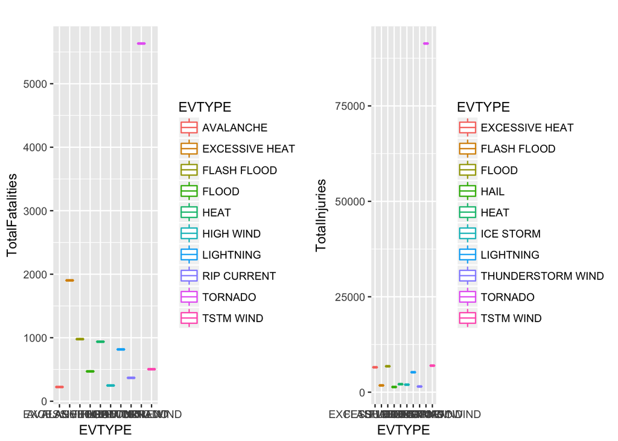

```r
fig1 <- grid.arrange(fatal, injury, ncol = 2)
```

```r
fig1
```

### Answering the Second Question

To remind ourselves of the second question, I’ve pasted it below so you do not have to scroll up:

2. Across the United States, which types of events have the greatest economic consequences?

Let’s go ahead and create a table of the totals for property damage and crop damage. We’ll create a table and graph that corresponds with the top 10 events that cause the most harm with respect to the economy when looking at greatest economic consequences.

Let’s deal with property damage first.

```r
storms.econ <- plyr::ddply(storms, plyr::.(EVTYPE), summarize, TotalProp = sum(PROPDMG), TotalCrop = sum(CROPDMG))

storms.prop <- arrange(storms.econ, desc(TotalProp))
head(storms.prop, 11)  # Figure out what the top 11 events are
```

```
##                EVTYPE    TotalProp TotalCrop
## 1         FLASH FLOOD 6.722990e+12 179200.46
## 2             TORNADO 5.281069e+09  99862.52
## 3  THUNDERSTORM WINDS 6.178790e+08  18614.93
## 4                HAIL 2.498844e+07 579578.28
## 5           TSTM WIND 1.336020e+06 109202.60
## 6           LIGHTNING 9.747381e+05   3580.61
## 7               FLOOD 8.999385e+05 168037.88
## 8   THUNDERSTORM WIND 8.768482e+05  66791.45
## 9           HIGH WIND 3.247316e+05  17283.21
## 10       WINTER STORM 1.327206e+05   1978.99
## 11         HEAVY SNOW 1.222655e+05   2165.72
```

```r
storms.prop <- filter(storms.prop, TotalProp > 1.222655e+05)    # use 11th highest value as cutoff

property <- ggplot(data = storms.prop, aes(x=EVTYPE, y=log(TotalProp))) + geom_boxplot()  + aes(colour=EVTYPE) + theme(legend.position="right") + labs(title="")
```

Then let’s deal with crop damage.

```r
storms.crop <- arrange(storms.econ, desc(TotalCrop))
head(storms.crop, 11)  # Figure out what the top 11 events are
```

```
##                EVTYPE    TotalProp TotalCrop
## 1                HAIL 2.498844e+07 579578.28
## 2         FLASH FLOOD 6.722990e+12 179200.46
## 3               FLOOD 8.999385e+05 168037.88
## 4           TSTM WIND 1.336020e+06 109202.60
## 5             TORNADO 5.281069e+09  99862.52
## 6   THUNDERSTORM WIND 8.768482e+05  66791.45
## 7             DROUGHT 4.099050e+03  33898.62
## 8  THUNDERSTORM WINDS 6.178790e+08  18614.93
## 9           HIGH WIND 3.247316e+05  17283.21
## 10         HEAVY RAIN 5.084214e+04  11122.80
## 11       FROST/FREEZE 9.685200e+02   7034.14
```

```r
storms.crop <- filter(storms.crop, TotalCrop > 7034.14)    # use 11th highest value as cutoff

croperty <- ggplot(data = storms.crop, aes(x=EVTYPE, y=log(TotalCrop))) + geom_boxplot()  + aes(colour=EVTYPE) + theme(legend.position="right") + labs(title="")     # lol croperty
```

Let’s go ahead and see what these two graphs look like in one figure.

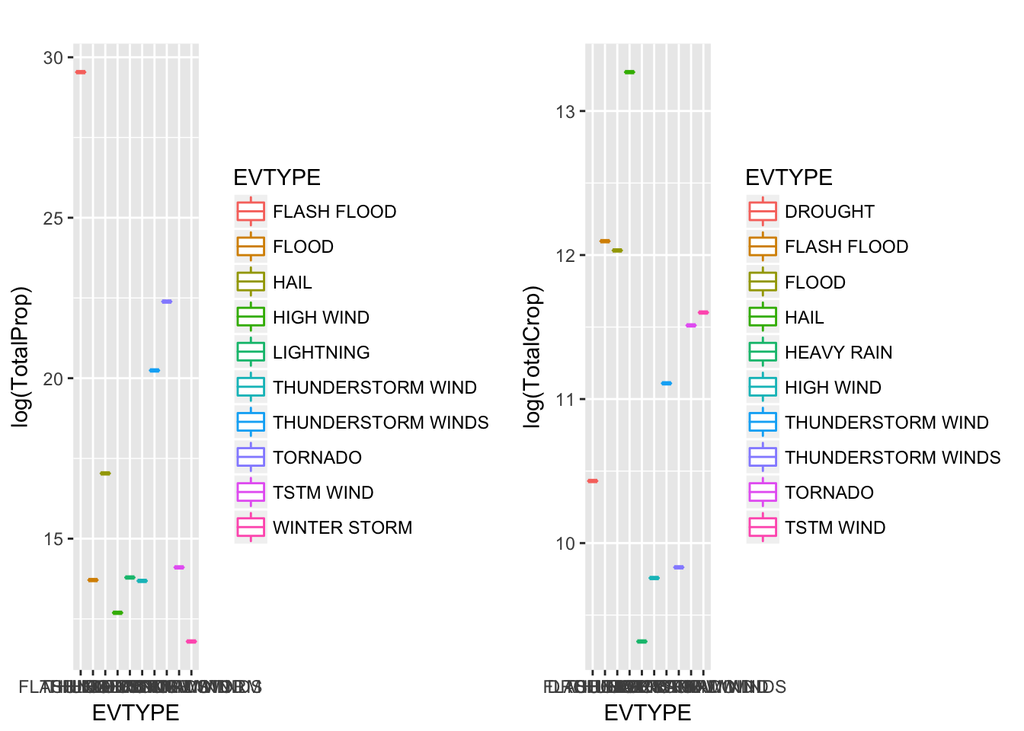

```r
fig2 <- grid.arrange(property, croperty, ncol = 2)
```

```r
fig2
```

Overall, we can say that weather can play a nasty game with humans and the market. As it currently stands, the U.S. isn’t paying much attention to the environment and developing public health initiatives and policy focusing on such matters, so perhaps that should be our next call to action.

I will admit that this is somewhat of a shallow analysis, but if allotted more time to complete and analyze this, then I would be able to determine other patterns that we may be missing with regards to natural weather events and fatal events.